# Alucce.TS

```python
#import the libraries we want to use
import pandas as pd
import numpy as np
import matplotlib.pyplot as plt

#this will display graths in line
%matplotlib inline
#specifiying how large to show the figure
plt.rcParams["figure.figsize"] =(8,6)
```

```python
superheros = pd.read_csv("superhero_vz_data.csv" , parse_dates = ["FIRST_YEAR"])
```

```python
superheros.head()
```

|  | UNIVERSE | page_id | name | urlslug | ID | ALIGN | IS_AVENGER | AVENGER_STATUS | AVENGER_YEAR | EYES | ... | SEX | SEXUALITY | ALIVE | APPEARANCES | FIRST_MONTH | FIRST_YEAR | DECEASED | RESURRECTED | Unnamed: 19 | Unnamed: 20 |
| --- | --- | --- | --- | --- | --- | --- | --- | --- | --- | --- | --- | --- | --- | --- | --- | --- | --- | --- | --- | --- | --- |
| 0 | DC | 1702 | Richard Occult (New Earth) | Richard_Occult_(New_Earth) | Secret Identity | ND | NO | ND | ND | Grey Eyes | ... | Male Characters | Heterosexual Characters | Living Characters | 125 | October | 1935 | ND | ND | NaN | NaN |
| 1 | DC | 158200 | Arthur Pendragon (New Earth) | Arthur_Pendragon_(New_Earth) | Public Identity | Good Characters | NO | ND | ND | Brown Eyes | ... | Male Characters | Heterosexual Characters | Living Characters | 41 | February | 1936 | ND | ND | NaN | NaN |
| 2 | DC | 289378 | Bedivere (New Earth) | Bedivere_(New_Earth) | ND | ND | NO | ND | ND | ND | ... | Male Characters | Heterosexual Characters | Living Characters | ND | February | 1936 | ND | ND | NaN | NaN |
| 3 | DC | 11333 | Franklin Delano Roosevelt (New Earth) | Franklin_Delano_Roosevelt_(New_Earth) | Public Identity | Good Characters | NO | ND | ND | ND | ... | Male Characters | Heterosexual Characters | Living Characters | 52 | March | 1936 | ND | ND | NaN | NaN |
| 4 | DC | 342641 | Gareth (New Earth) | Gareth_(New_Earth) | ND | ND | NO | ND | ND | ND | ... | Male Characters | Heterosexual Characters | Living Characters | 1 | February | 1936 | ND | ND | NaN | NaN |

5 rows × 21 columns

```python
## plot #1: When was most Superheros introduced?
```

[output not shown]

[output not shown]

```python
superheros.isnull().sum()# want to see what the values we have
```

```
UNIVERSE              0
page_id               0
name                  0
urlslug               0
ID                    0
ALIGN                 1
IS_AVENGER            0
AVENGER_STATUS        0
AVENGER_YEAR          0
EYES                  3
HAIR                  3
SEX                   0
SEXUALITY             0
ALIVE                 0
APPEARANCES           0
FIRST_MONTH           0
FIRST_YEAR            0
DECEASED              0
RESURRECTED           0
Unnamed: 19       23420
Unnamed: 20       23420
dtype: int64
```

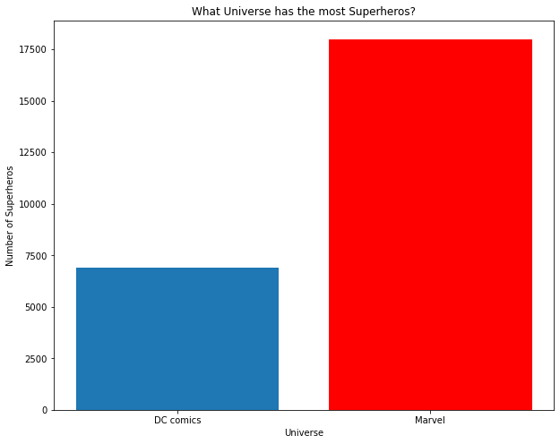

```python
#Plot #2: What universe has the most superheros?
# Make a bar chart
universe = ('DC comics', 'Marvel')
y_pos = np.arange(len(universe))
nr_superheros = [6896,18000]

fig, ax = plt.subplots()
fig.set_size_inches(10, 8)

barlist = ax.bar(y_pos, nr_superheros, align='center')
barlist[1].set_color('r')

plt.xticks(y_pos, universe)
plt.xlabel('Universe')
plt.ylabel('Number of Superheros')
plt.title('What Universe has the most Superheros?')

plt.rc('axes', titlesize=16)
plt.rc('axes', labelsize=12)
plt.rc('xtick', labelsize=12)
plt.rc('figure', titlesize=12)

plt.show()
#I had to get some help from whatching videos on YouTube to find how to implement a graph-CREDIT
```

```python
##plot #3:
# exclude missing values from total number of superheros
a = len(superheros)-superheros['ID'].isnull().sum()
```

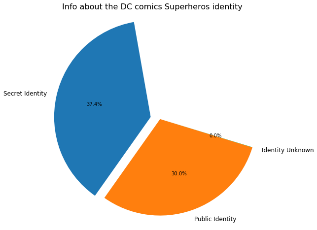

```python
# Make a pie chart
labels = 'Secret Identity', 'Public Identity', 'Identity Unknown'
sizes = [(len(superheros[superheros['ID'] == 'Secret Identity'])/a),
         (len(superheros[superheros['ID'] == 'Public Identity'])/a),
         (len(superheros[superheros['ID'] == 'Identity Unknown'])/a)]

explode = (0.1, 0, 0)  # split the first slice (i.e. 'Secret Identity')

fig, ax = plt.subplots()
fig.set_size_inches(10, 8)
ax.pie(sizes, explode=explode, labels=labels, autopct='%1.1f%%',
        shadow=False, startangle=100)
ax.axis('equal')

plt.title('Info about the DC comics Superheros identity')

plt.show()

#I had to get some help from whatching videos on YouTube to find how to implement the cart- CREDIT
# I don't really know the meaning of this message.
```

```python
#CREDIT to the lecture video I rewaatch and YouTube videos-
#In loooked up some online examples to guide me to come up with my own
```

# Part 1

The CVS file is a large contained a lot of the informations of DC and Marvel Univers charcaters. It's a file provided by Walt Hickey, giving us most of the informations we've ever wanted to konw ow about these characters. It has invormations like like characters hair colors to their Sexuality. The data was collected from GetHub. Data that is included are in like of name, ID, Align, year included, sex, sexuality, when they died, and appearance. The data that was not include is mostly these characters powers/abilities.

# Part 2

The different computational principles, expression and practices that I used to to conduct the data analysis are in the like of sequences, loops, events, conditionals, etc.. I identify a series of steps to create tasks, make decisions based on conditions and a lot more. Throughout working on these projects I manipulate my codes by debugging when I come on facing errors that occur when I write the codes wrong or miss a step of wrongful spelling or other typical mistakes.Aloso including booleans to conjunctions to combine or exclude keywords in a search. I used most of these computational definitions are taken from the computational thinking cheatsheet Developed by Dr. Wendy Norris; updated by Shiva Darian, to help me working on my codes to finalise these projects.

# Part 3

What are the different types of sexuality’s of the characters?  
For this question I wanted to go on and follow up with my them and Continue on expluring the involvement of women in the Marvel and DC univers. Analyzing what the sexuality of these characters are in the universe to make conection with how much involvements/introduction to the world. Also wanted to see what Universe, Marvel vs DC would most likely accept change.

```python
pd.crosstab(superheros["SEXUALITY"], superheros["ALIGN"], margins=True)
```

| ALIGN SEXUALITY | Bad Characters | Good Characters | ND | Neutral Characters | Reformed Criminals | All |
| --- | --- | --- | --- | --- | --- | --- |
| Bisexual Characters | 7 | 15 | 0 | 7 | 0 | 29 |
| Genderfluid Characters | 0 | 1 | 0 | 0 | 0 | 1 |
| Heterosexual Characters | 9590 | 7372 | 3402 | 2751 | 3 | 23118 |
| Homosexual Characters | 17 | 77 | 10 | 14 | 0 | 118 |
| ND | 2 | 117 | 24 | 6 | 0 | 149 |
| Pansexual Characters | 0 | 1 | 0 | 0 | 0 | 1 |
| Transgender Characters | 0 | 1 | 1 | 0 | 0 | 2 |
| Transvestites | 0 | 0 | 0 | 1 | 0 | 1 |
| All | 9616 | 7584 | 3437 | 2779 | 3 | 23419 |

What universe has the most superheros?  
Here I wanted to see which universe has the most Superheros and how it will realate to my them of why one universe is more like to introduce more female characters. I wanted to get the sense of these universes of which character is more to conected to the real world. I wanted to see the conection of how involve these universe were to let women characters be the main characters.

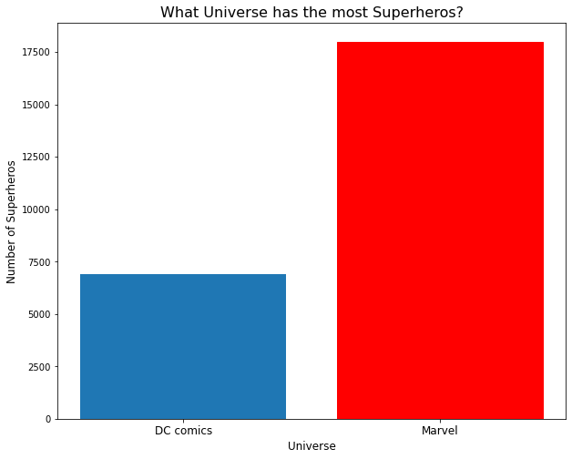

```python
universe = ('DC comics', 'Marvel')
y_pos = np.arange(len(universe))
nr_superheros = [6896,18000]

fig, ax = plt.subplots()
fig.set_size_inches(10, 8)

barlist = ax.bar(y_pos, nr_superheros, align='center')
barlist[1].set_color('r')

plt.xticks(y_pos, universe)
plt.xlabel('Universe')
plt.ylabel('Number of Superheros')
plt.title('What Universe has the most Superheros?')

plt.rc('axes', titlesize=16)
plt.rc('axes', labelsize=12)
plt.rc('xtick', labelsize=12)
plt.rc('figure', titlesize=12)

plt.show()
```

```python
# exclude missing values from total number of superheros
a = len(superheros)-superheros['ID'].isnull().sum()
```

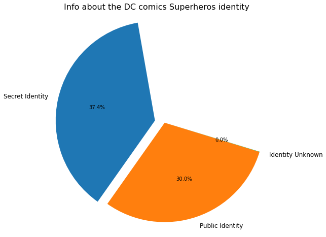

```python
# Make a pie chart
labels = 'Secret Identity', 'Public Identity', 'Identity Unknown'
sizes = [(len(superheros[superheros['ID'] == 'Secret Identity'])/a),
         (len(superheros[superheros['ID'] == 'Public Identity'])/a),
         (len(superheros[superheros['ID'] == 'Identity Unknown'])/a)]

explode = (0.1, 0, 0)  # split the first slice (i.e. 'Secret Identity')

fig, ax = plt.subplots()
fig.set_size_inches(10, 8)
ax.pie(sizes, explode=explode, labels=labels, autopct='%1.1f%%',
        shadow=False, startangle=100)
ax.axis('equal')

plt.title('Info about the DC comics Superheros identity')

plt.show()

#I had to get some help from whatching videos on YouTube to find how to implement the cart- CREDIT
# I don't really know the meaning of this message.
```

# Part 4

# Part 5

acknowledgments: Mainly where most of my help come crom is the article that was related to the CVS file by Walt Hickey. I also used GitHub to see some other provided data that I could relate to the data that I was already missing from the CVS file provided. I also watch some Youtube videos to guide me on fixing some the erros that came across in help of debugging. I also would like to credit the computational thinking cheatsheet Developed by Dr. Wendy Norris; updated by Shiva Darian, to help me working on my codes to finalise these projects. All these tools really help me to create this masterpiece of a project which was very fun to come up with.